[O’Hara on GitHub](https://github.com/oharac)

# Assign gear types to stressor categories

Compiled on Mon Sep 18 09:49:09 2023 by ohara

This script is a modification to Jamie Afflerbach’s script for the Recent Pace of Change project (Halpern et al. 2019), original scripts can be found in https://github.com/OHI-Science/impact_acceleration/tree/master/stressors.

This script assigns gear and species specific data to the raw data from [Watson (2017)](https://www.nature.com/articles/sdata201739) in order to classify catch as either **demersal** or **pelagic**, **destructive** or **nondestructive** and **high** or **low** bycatch. Using the gear classifications laid out in Halpern et al. (2008) Table S4, as well as species information from [FishBase](http://www.fishbase.org/search.php) shared by the [Sea Around Us Project](http://www.seaaroundus.org/) data we were able to assign gear classifications to each record.

# Summary

## Setup

```r
knitr::opts_chunk$set(fig.width = 6, fig.height = 4, message = FALSE, warning = FALSE)
library(terra)
library(oharac)
library(data.table)
library(tidyverse)
library(here)
source(here('common_fxns.R'))
```

# Get gear types from raw data

Jamie’s original script for RPoC (Halpern et al 2019) read in one of the raw data files from Watson (2017). The data used for RPoC only goes to 2015; for comparison to 2015-2017 used in spp CHI analysis, we will use an updated version of Watson database.

```r
### Jamie's original data for Halpern et al. 2019 looks like this:
# raw <- read_csv(here_anx('../../git-annex/impact_acceleration/stressors/comm_fish/data/Index.csv'))
# # A tibble: 6 × 12
#      ID  Year CountryName TaxonName      CommonName FleetGearName IndReported IndIUU
#   <dbl> <dbl> <chr>       <chr>          <chr>      <chr>               <dbl>  <dbl>
# 1     1  1983 Tunisia     Dicentrarchus  European/… Trawl midwat…        61.8   3.93
# 2     2  1987 Cyprus      Siganus        Rabbitfis… Trap                  0     0
# 3     3  2008 Sri Lanka   Euthynnus aff… Kawakawa   Gillnet            4335.  323.
# 4     4  2015 Viet Nam    Thunnus albac… Yellowfin… Pole and Lin…      3361.  359.
# 5     5  1974 Cuba        Merluccius ga… South Pac… Lines Non-tu…      3051.  781.
# 6     6  2014 Falkland Is Merluccius hu… Argentine… Lines Non-tu…      1578.  339.
# # … with 4 more variables: IndDiscards <dbl>, NIndReported <dbl>, NIndIUU <dbl>,
# #   NIndDiscards <dbl>

watson_dir <- here_anx('../../git-annex/globalprep/_raw_data',
                       'IMAS_GlobalFisheriesLandings/d2020')

w_codes_xlsx <- file.path(watson_dir, 'Codes_raw.xlsx')
# codes_sheets <- readxl::excel_sheets(codes_xlsx)
w_cell_df <- readxl::read_excel(w_codes_xlsx, sheet = 'Cell') %>%
  janitor::clean_names() %>%
  select(-c(x5:x7))

w_gear_df <- readxl::read_excel(w_codes_xlsx, sheet = 'Gear') %>%
  janitor::clean_names() %>%
  select(-c(x9:x10))
w_gear_clean <- w_gear_df %>%
  select(fleet_gear_name, f_gear_code) %>%
  distinct() %>%
  mutate(across(where(is.character), tolower))

w_taxa_df <- readxl::read_excel(w_codes_xlsx, sheet = 'Taxa') %>%
  janitor::clean_names() %>%
  select(-c(x8:taxonkey_11), taxonkey = taxonkey_1) %>%
  mutate(across(where(is.character), tolower))

message('Loading catch df and binding to gear and taxon df...')
w_catch_df <- readRDS(file.path(watson_dir, 'Catch2015_2019.rds')) %>%
  janitor::clean_names() %>%
  oharac::dt_join(w_gear_clean, by = c('f_gear_code'), type = 'left') %>%
  oharac::dt_join(w_taxa_df, by = 'taxonkey', type = 'left') %>%
  select(year = i_year, cell, ends_with('ind'),
         fleet_gear_name, taxon_name, common_name, descript)
### No distinct() here in case there were legit identical catch values
### distinguished by one of the dropped columns...

gear_vec <- w_gear_df$fleet_gear_name %>% unique() %>% sort()
```

```r
gear_cat_lookup <- read_csv('https://raw.githubusercontent.com/OHI-Science/impact_acceleration/master/stressors/comm_fish/gear_to_cat.csv') %>%
  janitor::clean_names() %>%
  mutate(across(where(is.character), tolower)) %>%
  ### this fix had been performed later in the script; moving up here:
  mutate(type = case_when(!is.na(type) ~ type,
                          str_detect(fleet_gear_name, 'trawl midwater|seine') ~ 'pelagic',
                          str_detect(fleet_gear_name, 'trawl|trap|dredge') ~ 'demersal',
                          TRUE ~ NA_character_))
knitr::kable(gear_cat_lookup)
```

| fleet_gear_name | bycatch | type | destruction |
| --- | --- | --- | --- |
| trawl | high | demersal | destructive |
| gillnet | high | NA | non-destructive |
| purse seine non-tuna | low | pelagic | non-destructive |
| lines non-tuna | low | NA | non-destructive |
| trawl midwater | high | pelagic | non-destructive |
| other | low | NA | non-destructive |
| dredge | high | demersal | destructive |
| trap | high | demersal | non-destructive |
| seine | high | pelagic | non-destructive |
| longlinetuna | high | pelagic | non-destructive |
| pole and line tuna | low | pelagic | non-destructive |
| purse seine tuna | low | pelagic | non-destructive |
| longline non-tuna | high | NA | non-destructive |

Ambiguous gear types are:

- Longline non-tuna
- Line non-tuna
- Gillnet
- Other

## Assign gear categories to data

Since we are just focusing on assigning gear types to the catch records we can eliminate some of the columns from the raw dataset and select unique records for taxon name, common name, taxon description, and fleet gear name.

```r
gear_taxon_df_raw <- w_catch_df %>%
  select(taxon_name, common_name, descript, fleet_gear_name) %>%
  distinct() %>%
  left_join(gear_cat_lookup, by = c('fleet_gear_name'))

DT::datatable(head(gear_taxon_df_raw, n=50),rownames = F)
```

| taxon_name | common_name | descript | fleet_gear_name | bycatch | type | destruction |
| --- | --- | --- | --- | --- | --- | --- |
| marine animals | marine animals | demersal &lt;30 cm | lines non-tuna | low |  | non-destructive |
| marine animals | marine animals | demersal &lt;30 cm | trap | high | demersal | non-destructive |
| marine animals | marine animals | demersal &lt;30 cm | trawl | high | demersal | destructive |
| marine animals | marine animals | demersal &lt;30 cm | seine | high | pelagic | non-destructive |
| marine animals | marine animals | demersal &lt;30 cm | purse seine non-tuna | low | pelagic | non-destructive |
| marine animals | marine animals | demersal &lt;30 cm | gillnet | high |  | non-destructive |
| miscellaneous diadromous fishes | diadromous fishes | demersal &gt;=90 cm | lines non-tuna | low |  | non-destructive |
| miscellaneous diadromous fishes | diadromous fishes | demersal &gt;=90 cm | trawl | high | demersal | destructive |
| clupeoids | herrings sardines anchovies | pelagic &lt;30 cm | trawl | high | demersal | destructive |
| clupeoids | herrings sardines anchovies | pelagic &lt;30 cm | trawl midwater | high | pelagic | non-destructive |

[output cut: 40 more lines]

# Assign species type categories

Many records need further clarification with regards to type of species (demersal or pelagic) for those ambiguous geartypes.

- Old method: We can use species data from the Sea Around Us Project to assign each species to the categories “demersal” or “pelagic”. The `taxon.dat` data provided by SAUP for the OHI 2016 assessment contains information on **Functional Group** which can be used to categorize species.
- This information is already included in the new Watson data so no need to access SAUP.

> Create new columns that tease out the type of species either demersal or pelagic using `stringr::str_detect`. Here we assign the *pelagic* category to all records which have a Functional Group Description containing: “shark”, “ray”, “reef”, “pelagic”, “Krill”, and “Cephalopods”. We assign the *demersal* category to all records that contain: “Shrimp”, “crab”, “lobster”, “demersal”, or “flatfish” in the Functional Group Description.

> The manual assignment of demersal or pelagic is based on my (Jamie’s) knowledge of these organisms. The assignments are fairly obvious except for “Marine animals”. For this group I have assigned them to the ‘pelagic’ category, with the justification that ‘pelagic’ might be more encompassing than ‘demersal’.

The old method seems problematic as there are many demersal sharks, rays, and cephalopods… but let’s try it.

```r
pel_descript <- c('shark', 'ray', 'reef', 'pelagic', 'krill', 'cephalopods')
dem_descript <- c('shrimp', 'crab', 'lobster', 'demersal', 'flatfish')
pel_comname  <- c('marlin', 'tuna', 'tuna', 'shark', 'sharks',
                  'herring', 'corvina', 'cartilaginous fishes', 'animals',
                  ### these added by Jamie later in the script, moving up here:
                  'venus', 'turbot', 'black porgy', 'gurnard', 'perch',
                  'herring', 'threadfish', 'needlefish', 'mullet', 'ariomma',
                  'silverfish', 'squid', 'larseni', 'bream', 'snipefishes',
                  'bonito', 'trout')
dem_comname  <- c('decapods', 'cucumbers', 'cockles', 'mollusca', 'molluscs',
                  'sea stars', 'starfishes', 'lobster', 'urchins',
                  ### these added by Jamie later in the script, moving up here:
                  'shell', 'rosefish', 'cockle', 'seacatfish', 'misty', 'warsaw',
                  'scallop', 'yellowedge', 'sailray', 'flounder', 'dogfish',
                  'snowy', 'sculpin', 'cods', 'cod', 'guitarfish', 'squillid',
                  'moray', 'lizard')

gear_taxon_df <- gear_taxon_df_raw %>%
  rename(type_from_gear = type) %>%
  mutate(type_from_taxa = case_when(str_detect(descript, smash2or(pel_descript)) ~ 'pelagic',
                                    str_detect(descript, smash2or(dem_descript)) ~ 'demersal',
                                    str_detect(common_name, smash2or(pel_comname)) ~ 'pelagic',
                                    str_detect(common_name, smash2or(dem_comname)) ~ 'demersal',
                                    TRUE ~ NA_character_))
# gear_taxon_df %>% filter(is.na(type_from_taxa))
# no missing types!

# DT::datatable(gear_taxon_df, rownames = F)
```

Now we have two different ways of categorizing each species, the first was by gear type and the second by functional group. We need to check and make sure these line up.

```r
gear_taxon_df %>%
  select(type_from_gear, type_from_taxa) %>%
  table()
```

```
##               type_from_taxa
## type_from_gear demersal pelagic
##       demersal      662     375
##       pelagic       176     453
```

```r
mismatch <- gear_taxon_df %>%
  filter(!is.na(type_from_gear)) %>%
  filter(type_from_gear != type_from_taxa) %>%
  distinct()
# DT::datatable(mismatch,rownames = F)
```

There remain 551 cases where we have mismatched types. Let’s examine the total catch for these mismatches compared to total catch for other geartypes, for the same taxon. The lines non-tuna, longline non-tuna, gillnet, and other are ambiguous from the gear type, so we must use the taxon to classify pelagic vs demersal. Drop these, and compare distributions of catch for the other gear types, match vs. non-match.

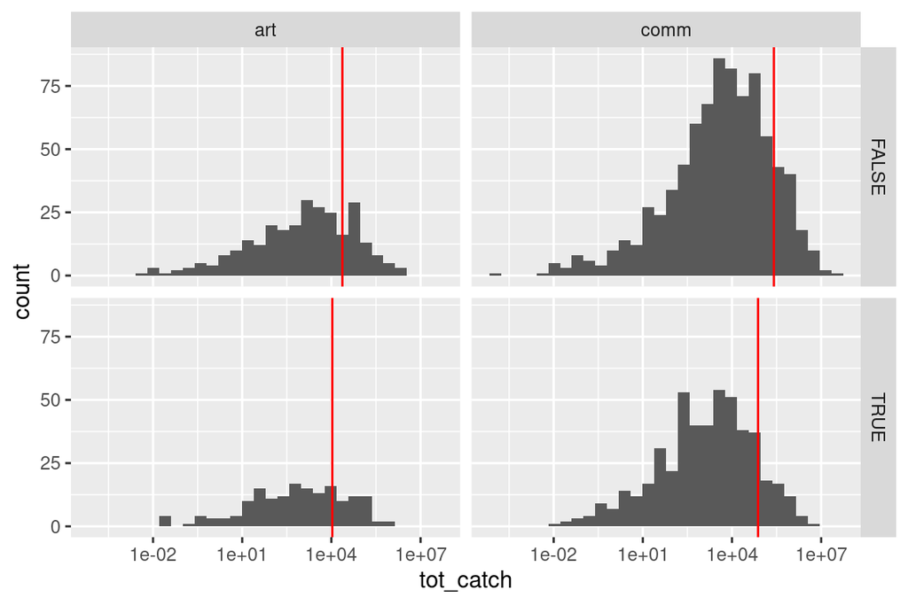

```r
catch_sum_df <- w_catch_df %>%
  data.table() %>%
  .[ , .(reported_ind  = sum(reported_ind),
         iuuind        = sum(iuuind),
         discards_ind  = sum(discards_ind),
         reported_nind = sum(reported_nind),
         iuunind       = sum(iuunind),
         discards_nind = sum(discards_nind)),
     by = .(fleet_gear_name, taxon_name, common_name, descript)]

mismatch_compare <- catch_sum_df %>%
  left_join(gear_taxon_df,
            by = c('fleet_gear_name', 'taxon_name', 'common_name', 'descript')) %>%
  filter(!is.na(type_from_gear)) %>% ### drop gillnet, non-tuna lines, and other
  mutate(mismatch = type_from_gear != type_from_taxa) %>%
  group_by(taxon_name, common_name, descript, type_from_gear, type_from_taxa, mismatch) %>%
  summarize(across(ends_with('ind'), sum)) %>%
  gather(catch_type, catch, ends_with('ind')) %>%
  mutate(catch_type = ifelse(str_detect(catch_type, 'nind'), 'art', 'comm')) %>%
  group_by(taxon_name, common_name, descript, catch_type, type_from_gear, type_from_taxa, mismatch) %>%
  summarize(tot_catch = sum(catch))

means_df <- mismatch_compare %>%
  group_by(mismatch, catch_type) %>%
  summarize(mean_catch = mean(tot_catch),
            sd_catch   = sd(tot_catch))

ggplot(mismatch_compare, aes(x = tot_catch)) +
  geom_histogram() +
  geom_vline(data = means_df, aes(xintercept = mean_catch), color = 'red') +
  scale_x_log10() +
  facet_grid(mismatch ~ catch_type)
```

The mismatches in (ideally) unambiguous gear types have about half or less of the catch for the matches…

For unambiguous gear types, assign the “type” to that noted by the gear. For the others, assign the type based on the taxon. Summarize taxon, gear type, etc. into the five commercial fishing stressors and write out as .csv. (Artisanal fishing stressor is just non-industrial, and blind to gear type).

```r
gear_tx_out_df <- gear_taxon_df %>%
  mutate(type = ifelse(is.na(type_from_gear), type_from_taxa, type_from_gear)) %>%
  select(taxon_name, common_name, fleet_gear_name, bycatch, type, destruction) %>%
  distinct()

write_csv(gear_tx_out_df, here('int/watson_gear_taxa_assignment.csv'))
```